# Statistical Inference Assignment: Part 2

Michael Crocco

### ToothGrowth Dataset Analysis

Overview: In this assignment, we will analyse and summarize the ToothGrowth Dataset. The dataset has three variables:

1. len: tooth length
2. supp: Supplement type (Vitamin C (as ascorbic acid), or Orange Juice)
3. dose: Dose in milligrams/day

First, let’s have a look at the data….

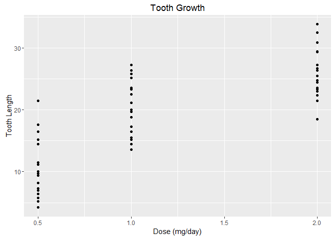

```r
library(ggplot2)
data("ToothGrowth")
vc <- ToothGrowth[ToothGrowth$supp=="VC",]
oj <- ToothGrowth[ToothGrowth$supp=="OJ",]

g <- ggplot(ToothGrowth, aes(dose, len)) + geom_point() + ggtitle("Tooth Growth")
g + labs(y="Tooth Length", x="Dose (mg/day)")
```

## There appears to be an increase in tooth growth as Vitamin C dosage is increased.

## Establish a hypothesis.

Our null hypothesis ($H_0$) will be that there is no effect to Tooth Length from increasing dosage.

## Assumptions:

*there is no material difference between the VC and OJ groups, that is, vitamin C from orange juice is no more or less effective for tooth growth than ascorbic acid

```r
low <- ToothGrowth[ToothGrowth$dose==0.5,]$len
med <- ToothGrowth[ToothGrowth$dose==1,]$len
high <- ToothGrowth[ToothGrowth$dose==2,]$len
```

Given the small sample sizes, we’ll conduct $t$-confidence intervals assuming unequal variance and treating the data as unpaired.

### First test the medium dose group versus the low

```r
t.test(med, low, paired = FALSE, var.equal = FALSE)
```

```
##
##  Welch Two Sample t-test
##
## data:  med and low
## t = 6.4766, df = 37.986, p-value = 1.268e-07
## alternative hypothesis: true difference in means is not equal to 0
## 95 percent confidence interval:
##   6.276219 11.983781
## sample estimates:
## mean of x mean of y
##    19.735    10.605
```

### Next, the high dose group versus the medium

```r
t.test(high, med, paired = FALSE, var.equal = FALSE)
```

```
##
##  Welch Two Sample t-test
##
## data:  high and med
## t = 4.9005, df = 37.101, p-value = 1.906e-05
## alternative hypothesis: true difference in means is not equal to 0
## 95 percent confidence interval:
##  3.733519 8.996481
## sample estimates:
## mean of x mean of y
##    26.100    19.735
```

### Finally, testing the high dosage group against the low is actually sufficient to test effectiveness of vitamin C in tooth growth.

```r
t.test(high, low, paired = FALSE, var.equal = FALSE)
```

```
##
##  Welch Two Sample t-test
##
## data:  high and low
## t = 11.799, df = 36.883, p-value = 4.398e-14
## alternative hypothesis: true difference in means is not equal to 0
## 95 percent confidence interval:
##  12.83383 18.15617
## sample estimates:
## mean of x mean of y
##    26.100    10.605
```